# Practical Machine Learning Week 4

Eugene Y

April 2, 2017

# Summary

One thing that people regularly do is quantify how much of a particular activity they do, but they rarely quantify how well they do it. In this project, the goal is to use data from accelerometers on the belt, forearm, arm, and dumbell of 6 participants, to predict the manner in which they did the exercise. The ‘classe’ variable in the training set is the manner variable.

# Data Source

The data for this project is from http://groupware.les.inf.puc-rio.br/har. Thanks a lot to their generosity.

```r
trainURL <- 'https://d396qusza40orc.cloudfront.net/predmachlearn/pml-training.csv'
testURL <- 'https://d396qusza40orc.cloudfront.net/predmachlearn/pml-testing.csv'
download.file(trainURL,destfile = 'trainset.csv')
download.file(testURL,destfile = 'testset.csv')
training <- fread('trainset.csv', na.strings=c('NA','#DIV/0!',''))
dim(training)
```

```
## [1] 19622   160
```

```r
testing <- fread('testset.csv', na.strings=c('NA','#DIV/0!',''))
dim(testing)
```

```
## [1]  20 160
```

The training set includes about 20K observations for 160 variables. The testing set has the same number of variables. I want to see the data quality of the training set, before I can decide if I can use all the 160 variables for predicting. In addition, I also want to see the outcome variable “classe”.

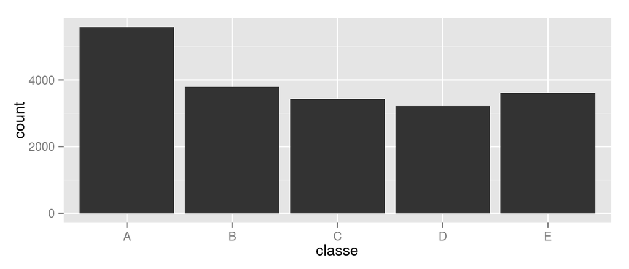

```r
qplot(data=training[,.(classe)],classe)
```

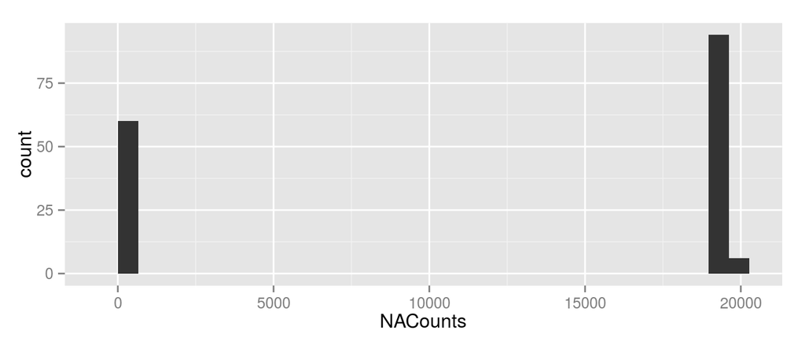

```r
NACounts <- colSums(is.na(training))   # count NA per column
qplot(data=data.frame(NACounts),NACounts)
```

There are five types of outcomes, which are classified as A, B, C, D, and E. Out of the 160 variables, 100 variables are not useful because they include significant amount of missing (NA) data points. Therefore, I only want to take the 60 columns as my new training set.

```r
to.be.removed <- names(NACounts[NACounts > 15000])
new.trainingset <- training[,!(colnames(training) %in% to.be.removed),with=F]
# remove column 'V1' because this column seems to be row number
new.trainingset[,V1:=NULL]
```

# Machine Learning Training and Validation

The training data set includes close to 20K observations. My machine is very slow when it comes to some machine learning algorithms, such as the random forests. So I only choose part of the training set as my training set.

## Linear discriminant analysis

```r
set.seed(2344)
prob <- c(0.2,0.7)
LDA.accu <- rep(NA,length(prob))
for(i in 1:length(prob)){
  inTrain <- createDataPartition(new.trainingset$classe,p=prob[i],list=F)
  TrainSet <- new.trainingset[inTrain,]
  Validation <- new.trainingset[-inTrain,]
  FitModel.LDA <- train(classe ~ ., method = 'lda', data = TrainSet)
  predi <- predict(FitModel.LDA, newdata = Validation)
  confM <- confusionMatrix(predi, Validation$classe)
  # LDA accuracy
  LDA.accu[i] <- confM$overall['Accuracy']
}
```

## Classification trees

```r
set.seed(24)
prob <- c(0.2,0.7)
Rpart.accu <- rep(NA,length(prob))
for(i in 1:length(prob)){
  inTrain <- createDataPartition(new.trainingset$classe,p=prob[i],list=F)
  TrainSet <- new.trainingset[inTrain,]
  Validation <- new.trainingset[-inTrain,]
  FitModel.Rpart <- train(classe ~ ., method = 'rpart', data = TrainSet)
  predi <- predict(FitModel.Rpart, newdata = Validation)
  confM <- confusionMatrix(predi, Validation$classe)
  Rpart.accu[i] <- confM$overall['Accuracy']
}
```

## Random forests

Random forest seems to have high demand for computation resource. My computer runs very slow when it came to this section.

```r
set.seed(924)
# This parallel processing package only works in UNIX
registerDoMC(4)
prob <- c(0.2,0.7)
RF.accu <- rep(NA,length(prob))
for(i in 1:length(prob)){
  inTrain <- createDataPartition(new.trainingset$classe,p=prob[i],list=F)
  TrainSet <- new.trainingset[inTrain,]
  Validation <- new.trainingset[-inTrain,]
  FitModel.RF <- train(classe ~ ., method = 'rf', data = TrainSet)
  predi <- predict(FitModel.RF, newdata = Validation)
  confM <- confusionMatrix(predi, Validation$classe)
  RF.accu[i] <- confM$overall['Accuracy']
}
```

## Generalized boosted regression models

```r
set.seed(98924)
# This parallel processing package only works in UNIX
registerDoMC(4)
prob <- c(0.2,0.7)
GBM.accu <- rep(NA,length(prob))
for(i in 1:length(prob)){
  inTrain <- createDataPartition(new.trainingset$classe,p=prob[i],list=F)
  TrainSet <- new.trainingset[inTrain,]
  Validation <- new.trainingset[-inTrain,]
  FitModel.GBM <- train(classe ~ ., method = 'gbm', data = TrainSet)
  predi <- predict(FitModel.GBM, newdata = Validation)
  confM <- confusionMatrix(predi, Validation$classe)
  GBM.accu[i] <- confM$overall['Accuracy']
}
```

## Compare algorithms

Prob 0.2 means that 20% of the data is used for training the model. Prob 0.7 means that 70% of the data is used for training the model.

```r
DF <- data.frame(prob,GBM.accu, RF.accu,
                 Rpart.accu, LDA.accu)
DF
```

```
##   prob  GBM.accu   RF.accu Rpart.accu  LDA.accu
## 1  0.2 0.9938834 0.9912074  0.5503026 0.8487416
## 2  0.7 0.9957519 0.9994902  0.5279524 0.8567545
```

# Predict

Random forest and generalized boosted model are prety accurate. Now let me predict using both models.

```r
predict(FitModel.RF, newdata = testing)
```

```
##  [1] B A B A A E D B A A B C B A E E A B B B
## Levels: A B C D E
```

```r
predict(FitModel.GBM, newdata = testing)
```

```
##  [1] B A B A A E D B A A B C B A E E A B B B
## Levels: A B C D E
```